# Nhóm 14 - Phân tích nhu cầu đặt phòng khách sạn - Proposal

Nguyễn Thị Diệu Hiền - 20133040

Huỳnh Nguyễn Như Nguyên - 20133019

19 Tháng 12 2022

# Introduction

## Giới thiệu

Khách sạn trực tiếp tạo ra doanh thu cho các nền kinh tế địa phương khi khách du lịch chi tiền trong khách sạn, nhà hàng và địa điểm giải trí. Ngành khách sạn đang phát triển, ngày càng có nhiều người chi tiền cho các hoạt động nghỉ dưỡng và giải trí. Mọi người chỉ có thể vào khách sạn khi đó là một kỳ nghỉ lễ hoặc một sự kiện đặc biệt, do đó nhu cầu ở trong phòng không phân bổ đều trong năm. Ngành khách sạn là một ngành rất biến động và việc đặt phòng phụ thuộc vào nhiều yếu tố như loại khách sạn, tính thời vụ, ngày trong tuần, v.v. Điều này làm cho việc phân tích các mẫu có sẵn trong dữ liệu quá khứ trở nên quan trọng hơn để giúp các khách sạn lập kế hoạch tốt hơn. Sử dụng dữ liệu lịch sử, các khách sạn có thể thực hiện các chiến dịch khác nhau để thúc đẩy hoạt động kinh doanh. Dữ liệu bao gồm khoảng 119.390 giao dịch đặt phòng từ 2 khách sạn: một khách sạn thành phố từ Lisbon (“City Hotel”) và một khách sạn nghỉ dưỡng từ Algarve (“Resort Hotel”). Bộ dữ liệu bao gồm các lượt đặt trước sẽ đến trong khoảng thời gian từ ngày 1 tháng 7 năm 2015 đến ngày 31 tháng 8 năm 2017, bao gồm các lượt đặt trước đã đến và các lượt đặt trước đã bị hủy. Có rất nhiều điều để khám phá từ dữ liệu này, nhưng nhóm sẽ chỉ tập trung vào dự báo nhu cầu. Nhóm sẽ đặt ra 5 câu hỏi như sau: 1. Các đặt phòng đến từ đâu? 2. Tần suất hủy bỏ đối với khách hàng và khả năng họ không đến nhận phòng là bao nhiêu? 3. Xu hướng về mức có thể tính cho khách hàng là bao nhiêu? 4. Khách sạn có thể kiếm được bao nhiêu doanh thu trên mỗi lần đặt phòng và bao nhiêu tiền đến từ mỗi quốc gia? 5. Dự đoán xu hướng hủy bỏ đặt phòng.

## Đề xuất phương pháp phân tích

Số lượng đật phòng theo quốc gia và kênh phân phối sẽ được trả lời các lượt đặt trước đến từ đâu. Tần suất hủy phòng và không đến nhận phòng sẽ được đánh giá bằng cách chia số lượng đặt phòng bị hủy cho tổng số lượng đặt phòng. Tỷ lệ hủy phòng sẽ được tính theo quốc gia để xác định quốc gia nào có tỷ lệ hủy phòng cao nhất. Doanh thu sẽ được tính từ dữ liệu đặt phòng. Điều này sẽ liên quan đến việc nhân thời gian lưu trú với tỷ lệ trung bình cho khách. Doanh thu thu được từ các đặt phòng bị hủy sẽ được lập bảng. Doanh thu đặt phòng trung bình sẽ được sử dụng để so sánh các đặt phòng từ các quốc gia khác nhau. Phát triển một mô hình dự đoán đặt phòng có hủy và không hủy bằng cách sử dụng hồi quy logistic.

## Mục đích phân tích

Việc phân tích nhằm mục đích đạt được cái nhìn sâu sắc thú vị về hành vi của khách hàng khi đặt phòng khách sạn. Để tối ưu hóa doanh thu mà khách sạn đạt được, ban quản lý thường sử dụng chiến lược định giá, một trong số đó là tăng giá phòng khi nhu cầu cao và khuyến mãi khi nhu cầu thấp. Do đó, khả năng dự báo chính xác nhu cầu trong tương lai là rất quan trọng và trở thành một phần quan trọng trong kế hoạch định giá. Nhu cầu đối với các phân khúc khách hàng khác nhau có thể khác nhau và việc dự báo trở nên khó khăn hơn vì nó có thể yêu cầu các mô hình khác nhau cho các phân khúc khác nhau. Những thông tin chi tiết này có thể hướng dẫn các khách sạn điều chỉnh chiến lược khách hàng của họ và chuẩn bị cho những điều chưa biết.

# Packages

```r
library(tidyverse)
library(knitr)
library(lubridate)
library(patchwork)
library(ISOcodes)
library(maps)
library(ggpubr)
```

Table 1: Package Summaries

| Packages | Version | Summary |
| --- | --- | --- |
| tidyverse | 1.3.2 | Các công cụ R cho thao tác và trực quan hóa dữ liệu |
| knitr | 1.4.0 | Tạo dymamic report, đặc biệt là hiển thị bảng |
| lubridate | 1.8.0 | Package xử lý ngày tháng |
| ISOcodes | 2022.09.29 | Chứa tập dữ liệu được sử dụng để dịch mã quốc gia ISO thành tên quốc gia |
| patchwork | 1.1.2 | Package để kết hợp nhiều ggplot2 thành một hình |

# Data Dictionary

Dưới đây là bảng mô tả các biến

Table 2: Data Description

| Variable | Type | Description |
| --- | --- | --- |
| hotel | factor | Loại khách sạn (City Hotel or Resort Hotel) |
| is_canceled | integer | Cho biết đặt chỗ có bị hủy (1) hay không (0) |
| lead_time | integer | Số ngày từ khi đặt phòng đến khi khách đến khách sạn. Được tính bằng cách trừ ngày đặt phòng từ ngày đến |
| arrival_date_year | integer | Năm của ngày đến |
| arrival_date_month | factor | Tháng của ngày đến |
| arrival_date_week_number | integer | Ngày đến thuộc tuần thứ mấy trong năm |
| arrival_date_day_of_month | integer | Ngày của ngày đến |
| stays_in_weekend_nights | integer | Số đêm cuối tuần (thứ bảy hoặc chủ nhật) mà khách lưu trú hoặc đặt phòng để lưu trú tại khách sạn |
| stays_in_week_nights | integer | Số đêm trong tuần (từ thứ Hai đến thứ Sáu) mà khách lưu trú hoặc đặt phòng để lưu trú tại khách sạn |
| adults | integer | Số người lớn |
| children | integer | Số trẻ em |
| babies | integer | Số trẻ sơ sinh |
| meal | factor | Loại bữa ăn đã đặt. Không xác định/SC - không có gói bữa ăn; BB - Giường & Bữa sáng; HB - Bao ăn nửa bữa (bữa sáng và một bữa ăn khác - thường là bữa tối); FB - Bao ăn 3 bữa (sáng, trưa và tối) |
| country | factor | Quốc gia. Các danh mục được trình bày ở định dạng ISO 3155–3: 2013 |
| market_segment | factor | Chỉ định phân khúc thị trường. “TA” - Đại lý du lịch (Bán lẻ các gói du lịch của TO hoặc bên thứ ba); “TO” - Nhà điều hành tour (công ty kinh doanh lữ hành, một đơn vị kinh doanh chuyên sắp xếp các dị… |
| distribution_channel | factor | Kênh phân phối đặt trước. Thuật ngữ “TA” có nghĩa là “Đại lý du lịch” và “TO” có nghĩa là “Nhà điều hành tour” |
| is_repeated_guest | integer | Cho biết đây có phải khách hàng quay lại/ khách hàng đã đặt phòng trước đây rồi (1) hay không (0) |
| previous_cancellations | integer | Số lần khách hàng đã hủy đặt chỗ trong quá khứ |
| previous_bookings_not_canceled | integer | Số lần đặt chỗ trước đó không bị khách hàng hủy trước lượt đặt chỗ hiện tại |
| reserved_room_type | factor | Mã loại phòng đã đặt trước. Trình bày dưới dạng mã thay vì nêu rõ vì lý do ẩn danh. |
| assigned_room_type | factor | Mã cho loại phòng được chỉ định cho đặt phòng. Đôi khi loại phòng được chỉ định khác với loại phòng đã đặt trước vì lý do hoạt động của khách sạn (ví dụ: đặt trước quá nhiều) hoặc do yêu cầu của khách… |
| booking_changes | integer | Số thay đổi/sửa đổi đối với đặt phòng kể từ thời điểm đặt phòng được nhập trên PMS cho đến thời điểm nhận phòng hoặc hủy bỏ |
| deposit_type | factor | Cho biết khách hàng có đặt cọc trước hay không và đặt cọc trước với kiểu như thế nào. Biến này có thể giả định 3 loại: No deposit - không đặt cọc trước; No Refund - trả trước toàn bộ chi phí; Refundab… |
| agent | factor | ID của đại lý du lịch thực hiện việc đặt phòng |
| company | factor | ID của công ty/tổ chức đã thực hiện đặt phòng hoặc chịu trách nhiệm thanh toán đặt phòng. |
| days_in_waiting_list | integer | Số ngày đặt chỗ trong danh sách chờ trước khi nó được xác nhận cho khách hàng |
| customer_type | factor | Loại đặt phòng. Có 4 loại: Contract - đặt phòng có hợp đồng; Group - đặt phòng có liên quan đến một nhóm; Transient - Đặt phòng không thuộc hợp đồng hoặc nhóm và không liên quan đến đặt phòng tạm thời… |
| adr | numeric | Giá trung bình hàng ngày được xác định bằng cách chia tổng của tất cả các giao dịch lưu trú cho tổng số đêm lưu trú |
| required_car_parking_spaces | integer | Số lượng chỗ đậu xe ô tô theo yêu cầu của khách hàng |
| total_of_special_requests | integer | Số lượng yêu cầu đặc biệt của khách hàng (ví dụ: 2 giường đơn hoặc tầng cao) |
| reservation_status | factor | Cho biết khách hàng có hủy đặt chỗ hay không (“Canceled”); khách đã nhận phòng và sau đó trả phòng (“Check-Out”); hoặc không bao giờ xuất hiện mà không có lời giải thích với khách sạn (“No-Show”) |
| reservation_status_date | factor | Biến này có thể được sử dụng cùng với Trạng thái đặt chỗ (reservation_status) để biết khi nào đặt phòng bị hủy hoặc khi nào khách hàng đã trả phòng khách sạn |

# Data Preparation

Table 3: Subsection Variables

| Subsection | Variables |
| --- | --- |
| Arrival Date | arrival_date_year, arrival_date_month, arrival_date_week_number, arrival_date_day_of_month |
| Guest Demographics | adults, children, babies, country |
| Reservation Status | reservation_status, reservation_status_date, is_canceled, lead_time, days_in_waiting_list |
| User Karma | is_repeated_guest, previous_cancellations, previous_bookings_not_cancelled |
| Guest Accommodations | stays_in_weekend_nights, stays_in_week_nights, reserved_room_type, assigned_room_type, meals, required_car_parking_spaces, total_of_special_requests |
| Booking Information | hotel, market_segment, distribution_channel, booking_changes, deposit_type, agent, company, customer_type |
| Average Daily Rate | adr |

## Import Data

Dữ liệu ban đầu từ bài báo “Hotel Booking Demand Datasets” được viết bởi Nuno Antonio, Ana Almeida, and Luis Nunes, February 2019.[1] Nhóm đã tải xuống dữ liệu đã được làm sạch từ #TidyTuesday.[2]

```r
#load tập dữ liệu
hotels <- read_csv("data/hotels.csv")
```

```r
#Xem cấu trúc của dữ liệu
glimpse(hotels)
```

```
## Rows: 119,390
## Columns: 32
## $ hotel                          <chr> "Resort Hotel", "Resort Hotel", "Resort…
## $ is_canceled                    <dbl> 0, 0, 0, 0, 0, 0, 0, 0, 1, 1, 1, 0, 0, …
## $ lead_time                      <dbl> 342, 737, 7, 13, 14, 14, 0, 9, 85, 75, …
## $ arrival_date_year              <dbl> 2015, 2015, 2015, 2015, 2015, 2015, 201…
## $ arrival_date_month             <chr> "July", "July", "July", "July", "July",…
## $ arrival_date_week_number       <dbl> 27, 27, 27, 27, 27, 27, 27, 27, 27, 27,…
## $ arrival_date_day_of_month      <dbl> 1, 1, 1, 1, 1, 1, 1, 1, 1, 1, 1, 1, 1, …
## $ stays_in_weekend_nights        <dbl> 0, 0, 0, 0, 0, 0, 0, 0, 0, 0, 0, 0, 0, …
## $ stays_in_week_nights           <dbl> 0, 0, 1, 1, 2, 2, 2, 2, 3, 3, 4, 4, 4, …
## $ adults                         <dbl> 2, 2, 1, 1, 2, 2, 2, 2, 2, 2, 2, 2, 2, …
## $ children                       <dbl> 0, 0, 0, 0, 0, 0, 0, 0, 0, 0, 0, 0, 0, …
## $ babies                         <dbl> 0, 0, 0, 0, 0, 0, 0, 0, 0, 0, 0, 0, 0, …
## $ meal                           <chr> "BB", "BB", "BB", "BB", "BB", "BB", "BB…
```

[output cut: 19 more lines]

## Arrival Date

`arrival_date_year`, `arrival_date_month`, `arrival_date_week_number` và `arrival_date_day_of_month` đều chỉ thời gian khách đã đến khách sạn nên sẽ được hợp thành một biến duy nhất `arrival_date`

### Hợp nhất các biến Arrival Date

Hợp nhất các biến trên thành một biến duy nhất `arrival_date` bằng cách dùng `lubridate`

```r
hotels %>%
  #khởi tạo một biến arrival_date với ngày, tháng, năm
  mutate(arrival_date = paste(arrival_date_day_of_month,
                              arrival_date_month,
                              arrival_date_year,
                              sep = "/")) %>%
  #chuyển character về date
  mutate(arrival_date = dmy(arrival_date)) %>%

  #loại bỏ các biến sau khi hợp nhất khỏi hotels
  select(-c(arrival_date_year,
            arrival_date_month,
            arrival_date_day_of_month,
            arrival_date_week_number)) -> hotels
```

## Guest Demographics

Trong phần này sẽ xử lý với các biến `adults`, `children`, `babies` và `country`. Xóa bỏ các quan sát không có khách và các quan sát với country là `NA`

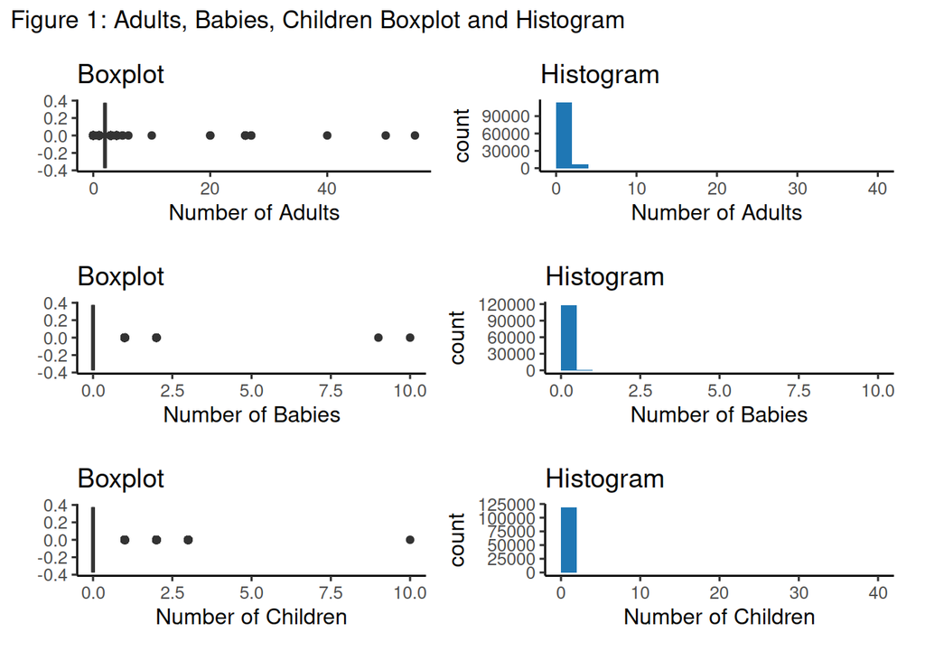

```r
#================== ADULTS VARIABLE =================================
  #tạo biểu đồ boxplot cho adults
  hotels %>%
    ggplot(aes(x = adults)) +
    geom_boxplot(fill = "#FF7F0E") +
    theme_classic2() +
    labs(x = "Number of Adults", title = "Boxplot") -> adults_boxplot

  #tạo biểu đồ histogram cho adults
  hotels %>%
    ggplot(aes(x = adults)) +
    geom_histogram(fill = "#1F77B4", breaks=seq(0,40,2)) +
    theme_classic2()+
    labs(x = "Number of Adults", title = "Histogram") -> adults_histogram

  #kết hợp 2 biểu đồ
  adults_boxplot + adults_histogram -> adults_boxplot_and_histogram



#============ CHILDREN VARIABLE =========================

  #Có 4 `NA` cho biến `children`, có thể là do lỗi của việc nhập dữ liệu. Các `NA` này sẽ được coi là `0`
  hotels %>%
    mutate(children = case_when(is.na(children) ~ 0,
                                TRUE ~ children)
           ) -> hotels
  #Boxplot
  hotels %>%
    ggplot(aes(x = children)) +
      geom_boxplot(fill = "#FF7F0E") +
      theme_classic2() +
      labs(x = "Number of Children", title = "Boxplot") -> children_boxplot
  #Histogram
  hotels %>%
    ggplot(aes(x = children)) +
      geom_histogram(fill = "#1F77B4", breaks=seq(0,40,2)) +
      theme_classic2() +
      labs(x = "Number of Children", title = "Histogram") -> children_histogram

  children_boxplot + children_histogram -> children_boxplot_and_histogram

#======================== BABIES VARIABLE ======================================

  #boxplot
  hotels %>%
    ggplot(aes(x = babies)) +
      geom_boxplot(fill = "#FF7F0E") +
      theme_classic2() +
      labs(x = "Number of Babies", title = "Boxplot") -> babies_boxplot

  #histogram
  hotels %>%
    ggplot(aes(x = babies)) +
      geom_histogram(fill = "#1F77B4", breaks=seq(0,10,0.5)) +
      theme_classic2() +
      labs(x = "Number of Babies", title = "Histogram") -> babies_histogram

  babies_boxplot + babies_histogram -> babies_boxplot_and_histogram

#==================== COUNTRY VARIABLE =========================================
  #Đối với biến `country` đầu tiên chúng ta chuyển giá trị `NULL` thành `NA`
  hotels %>%
  mutate(country = na_if(country, "NULL")) -> hotels

  #Sau đó loại bỏ các giá trị `NA` này vì mỗi khách phải có một `country` nhất định và chuyển `country` về dạng factor
  hotels %>%
  filter(!is.na(country)) %>%
  mutate(country = as.factor(country)) -> hotels

#===============================================================================

ggarrange(adults_boxplot_and_histogram, babies_boxplot_and_histogram,children_boxplot_and_histogram, nrow = 3, ncol = 1) +
  plot_annotation("Figure 1: Adults, Babies, Children Boxplot and Histogram")
```

**Nhận xét:** Biểu đồ boxplot và histogram trong hình 1 trên cho thấy - Hầu hết các quan sát dao động từ 1-3 khách. Tuy nhiên có một vài trường hợp nhiều hơn, điều này xảy ra có thể do một số lượt đặt phòng cho các đại lý du lịch hoặc công ty lữ hành thực hiện. Do đó,không nên xóa các biến này . - Hầu hết khách đến khách sạn mà không mang theo trẻ em. Số trẻ em lớn nhất là 10 - Phần lớn khách không mang theo trẻ sơ sinh đến các khách sạn này. Số lượng trẻ sơ sinh lớn nhất được quan sát là 10. Kết quả này không được coi là outlier vì có thể có một số trường hợp đặc biệt như vậy. - Có 180 quan sát mà không có khách nào được ghi lại cho một đặt phòng. Chúng ta sẽ loại bỏ nó đi

```r
hotels %>%
  filter(adults + children + babies >= 1) -> hotels
```

## Reservation Status

Phần này mô tả sự đặt phòng của khách và sẽ làm việc với các biến `reservation_status`, `reservation_status_date`, `is_canceled, lead_time`, `days_in_waiting_list`.

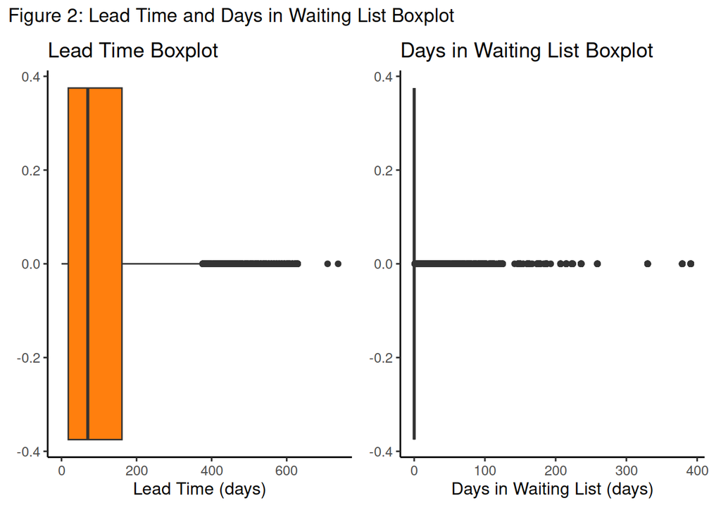

```r
#==================== IS_CANCELLED VARIABLE ====================================

#Chuyển `is_canceled` về dạng logic
hotels %>%
  mutate(is_canceled = as.logical(is_canceled)) -> hotels

#===================== LEAD_TIME VARIABLE ======================================

#Boxplot de xac dinh outlier
hotels %>%
  ggplot(aes(lead_time)) +
    geom_boxplot(fill = "#FF7F0E") +
    theme_classic2() +
    labs(x = "Lead Time (days)",
         title = "Lead Time Boxplot") -> lead_time_boxplot

#===================== DAY_IN_WAITING_LIST VARIABLE ============================
hotels %>%
  ggplot(aes(days_in_waiting_list)) +
    geom_boxplot(fill = "#FF7F0E") +
    theme_classic2() +
    labs(x = "Days in Waiting List (days)",
         title = "Days in Waiting List Boxplot") -> days_in_waiting_list_boxplot
#===================== RESERVATION_STATUS VARIABLE =============================

#Chuyển về dạng factor
hotels %>%
  mutate(reservation_status = as.factor(reservation_status)) -> hotels

#===============================================================================

ggarrange(lead_time_boxplot, days_in_waiting_list_boxplot) +
  plot_annotation("Figure 2: Lead Time and Days in Waiting List Boxplot")
```

**Nhận xét:** Dựa vào hình 2 - Chúng ta sẽ loại bỏ các quan sát có `lead_time` > 625 khỏi tạp dữ liệu.

```r
hotels %>%
  filter(lead_time <= 625) -> hotels
```

- Các `days_in_waiting_list` > 200 là outlier. Ta sẽ tiến hành loại bỏ

```r
hotels %>%
  filter(days_in_waiting_list <= 200) -> hotels
```

## User Karma

User Karma chứa các biến số phản ánh hành vi của người dùng đối với khách sạn. Phần này sẽ làm việc với các biến `is_repeated_guest`, `previous_cancellations`, và `previous_bookings_not_cancelled`.

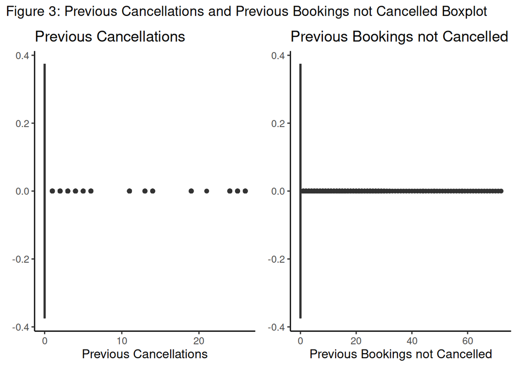

```r
#==================== IS_REPEATED_GUEST VARIABLE ===============================

#Chuyển về dạng logical
hotels %>%
  mutate(is_repeated_guest = as.logical(is_repeated_guest)) -> hotels

#==================== PREVIOUS_CANCELLATIONS VARIABLE ===========================
hotels %>%
  ggplot(aes(previous_cancellations)) +
    geom_boxplot(fill = "#FF7F0E") +
    theme_classic2() +
    labs(x = "Previous Cancellations",
         title = "Previous Cancellations") -> previous_cancellations_boxplot

#=================PREVIOUS_BOOKINGS_NOT_CANCELLED VARIABLE =====================
hotels %>%
  ggplot(aes(previous_bookings_not_canceled)) +
    geom_boxplot(fill = "#FF7F0E") +
    theme_classic2() +
    labs(x = "Previous Bookings not Cancelled",
         title = "Previous Bookings not Cancelled") -> previous_bookings_not_cancelled_boxplot

#===============================================================================
ggarrange(previous_cancellations_boxplot, previous_bookings_not_cancelled_boxplot) +
  plot_annotation("Figure 3: Previous Cancellations and Previous Bookings not Cancelled Boxplot ")
```

**Nhận xét:** Dựa theo hình 3 - `previous_cancellations` > 10 là outlier nhưng sẽ không loại bỏ để tránh phạt các đại lý du lịch và các công ty đặt phòng sẽ phải hủy thay cho khách - Không chỉ rõ một ngưỡng rõ ràng cho các trường hợp outlier của `previous_bookings_not_cancelled`

## Guest Accommodations

Phần này bao gồm các biến mô tả chỗ ở mà mỗi đơn đặt phòng nhận được. Cụ thẻ là `stays_in_weekend_nights`, `stays_in_week_nights`, `reserved_room_type`, `assigned_room_type`, `meals`, `required_car_parking_spaces`, và `total_of_special_requests`

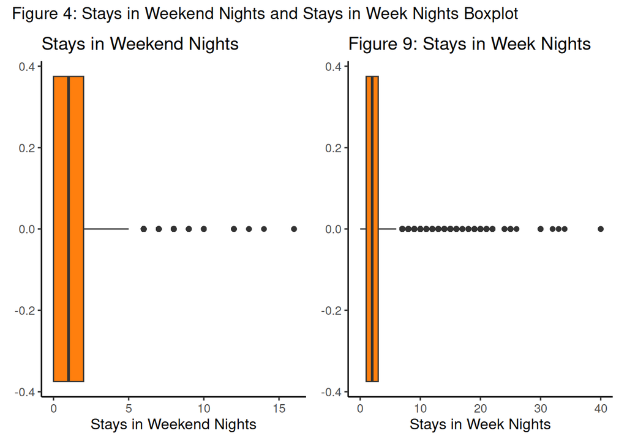

```r
#===================== STAYS_IN_WEEKEND_NIGHTS VARIABLE ========================
hotels %>%
  ggplot(aes(stays_in_weekend_nights)) +
    geom_boxplot(fill = "#FF7F0E") +
    theme_classic2() +
    labs(x = "Stays in Weekend Nights",
         title = "Stays in Weekend Nights") -> stays_in_weekend_nights_boxplot
#========================== STAY_IN_WEEK_NIGHTS ================================

hotels %>%
  ggplot(aes(stays_in_week_nights)) +
    geom_boxplot(fill = "#FF7F0E") +
    theme_classic2() +
    labs(x = "Stays in Week Nights",
         title = "Figure 9: Stays in Week Nights") -> stays_in_week_nights_boxplot
#============== `reserved_room_type, assigned_room_type` variables==============

#Đối với các biến này chỉ cần chuyển về dạng factor
hotels %>%
  mutate(reserved_room_type = as.factor(reserved_room_type)) -> hotels

#=========================== `meals` variable ==================================

#Đối với biến `meals`, chúng ta sẽ chuyển các ký tự viết tắt về dạng đầy đủ sau đó chuyển về dạng factor
hotels %>%
  mutate(meal = case_when(meal == "Undefined" ~ "No Meal Plan",
                          meal == "SC" ~ "No Meal Plan",
                          meal == "BB" ~ "Bed and Breakfast",
                          meal == "HB" ~ "Half Board",
                          meal == "FB" ~ "Full Board")
         ) %>%
  mutate(meal = as.factor(meal)) -> hotels

#===============================================================================

ggarrange(stays_in_weekend_nights_boxplot, stays_in_week_nights_boxplot) +
  plot_annotation(" Figure 4: Stays in Weekend Nights and Stays in Week Nights Boxplot")
```

**Nhận xét:** Dựa theo hình 4 `stays_in_weekend_nights` và `stays_in_weeks_nights` > 5 là outlier nhưng không bị loại bỏ vì có những trường hợp kéo dài thời gian lưu trú

## Booking Information

Phần này sẽ làm việc với các biến mô tả các thực thể tham gia vào việc đặt phòng. `hotel, market_segment`, `distribution_channel`, `booking_changes`, `deposit_type`, `agent`, `company`, và `customer_type`

```r
#======================== `hotel` variable =====================================
    hotels %>%
      mutate(hotel = as.factor(hotel)) -> hotels

#========================= `market_segment` variable ===========================

  #Loại bỏ các giá trị "Undefined" và chuyển biến này về dạng factor
  hotels %>%
    filter(market_segment != "Undefined") %>%
    mutate(market_segment = as.factor(market_segment)) -> hotels

#======================== `distribution_channel` variable ======================

  #Tương tự với `market_segment`, ta cũng loại bỏ "Undefined" và chuyển `distribution_channel` về dạng factor
  hotels %>%
  filter(distribution_channel != "Undefined") %>%
  mutate(distribution_channel = as.factor(distribution_channel)) -> hotels

#========================= `agent`, `company` variables ========================
  #Chuyển `NULL` về `NA` sau đó chuyển về kiểu numeric
  hotels %>%
  mutate(agent = na_if(agent, "NULL")) %>%
  mutate(agent = as.numeric(agent)) -> hotels

  hotels %>%
  mutate(company = na_if(company, "NULL")) %>%
  mutate(company = as.numeric(company)) -> hotels

#========================= `customer_type` variable ============================
  #Chuyển biến này về dạng factor
  hotels %>%
    mutate(customer_type = as.factor(customer_type)) -> hotels
```

## Average Daily Rate

Doanh thu trung bình hàng ngày được tính bằng cách chia tổng số giao dịch liên quan đến đặt phòng cho tổng số đêm

```r
hotels %>%
  select(adr) %>%
  summary
```

```
##       adr
##  Min.   :  -6.38
##  1st Qu.:  70.00
##  Median :  95.00
##  Mean   : 102.20
##  3rd Qu.: 126.00
##  Max.   :5400.00
```

– Ta sẽ loại bỏ giá trị âm

```r
hotels %>%
  filter(adr >= 0) -> hotels
```

# Data summary

Dùng hàm `glimse` để xem lại cấu trúc của dữ liệu

```r
glimpse(hotels)
```

```
## Rows: 118,450
## Columns: 29
## $ hotel                          <fct> Resort Hotel, Resort Hotel, Resort Hote…
## $ is_canceled                    <lgl> FALSE, FALSE, FALSE, FALSE, FALSE, FALS…
## $ lead_time                      <dbl> 342, 7, 13, 14, 14, 0, 9, 85, 75, 23, 3…
## $ stays_in_weekend_nights        <dbl> 0, 0, 0, 0, 0, 0, 0, 0, 0, 0, 0, 0, 0, …
## $ stays_in_week_nights           <dbl> 0, 1, 1, 2, 2, 2, 2, 3, 3, 4, 4, 4, 4, …
## $ adults                         <dbl> 2, 1, 1, 2, 2, 2, 2, 2, 2, 2, 2, 2, 2, …
## $ children                       <dbl> 0, 0, 0, 0, 0, 0, 0, 0, 0, 0, 0, 0, 1, …
## $ babies                         <dbl> 0, 0, 0, 0, 0, 0, 0, 0, 0, 0, 0, 0, 0, …
## $ meal                           <fct> Bed and Breakfast, Bed and Breakfast, B…
## $ country                        <fct> PRT, GBR, GBR, GBR, GBR, PRT, PRT, PRT,…
## $ market_segment                 <fct> Direct, Direct, Corporate, Online TA, O…
## $ distribution_channel           <fct> Direct, Direct, Corporate, TA/TO, TA/TO…
## $ is_repeated_guest              <lgl> FALSE, FALSE, FALSE, FALSE, FALSE, FALS…
```

[output cut: 16 more lines]

**Nhận xét:** Sau khi loại bỏ các giá trị NA, tập dữ liệu còn lại 118450 quan sát. Chỉ 0,79% các quan sát bị loại bỏ trong quá trình chuẩn bị dữ liệu.

## Arrival Date

```r
#Dếm số đặt phòng mỗi tháng
hotels %>%
  count(month(arrival_date, label = TRUE, abbr = FALSE)) %>%
  kable(format = "pipe",
        col.names = c("Arrival Month", "Total Number of Bookings"),
        caption = "Table 4: Total Number of Bookings by Month")
```

Table 4: Total Number of Bookings by Month

| Arrival Month | Total Number of Bookings |
| --- | --- |
| Tháng 1 | 5866 |
| Tháng 2 | 7996 |
| Tháng 3 | 9694 |
| Tháng 4 | 11028 |
| Tháng 5 | 11687 |
| Tháng 6 | 10917 |
| Tháng 7 | 12609 |
| Tháng 8 | 13836 |
| Tháng 9 | 10369 |
| Tháng 10 | 11037 |
| Tháng 11 | 6701 |
| Tháng 12 | 6710 |

**Nhận xét:** Theo Bảng 4, những tháng mùa hè là bận rộn nhất đối với các khách sạn dựa trên ngày đến đã đặt trước. Các tháng mùa đông ít phổ biến hơn đáng kể, với tháng Giêng có ít đặt phòng nhất là 5866.

## Guest Demographics

Các biến `adults`, `children`, `babies` có dữ liệu tương tự nhau. Bảng 5 dưới đây tóm tắt sự phân bố của chúng

```r
hotels %>%
  select(adults, children, babies) %>%
  summarise(across(.fns = summary)) -> guest_age_summary

tibble(c("Min.", "1st Qu.", "Median", "Mean", "3rd Qu.", "Max."),
       guest_age_summary) -> guest_age_summary

guest_age_summary %>%
  kable(format = "pipe",
        col.names = c("", "Adults", "Children", "Babies"),
        caption = "Table 5: Guest Age Demographics")
```

Table 5: Guest Age Demographics

|  | Adults | Children | Babies |
| --- | --- | --- | --- |
| Min. | 0.000000 | 0.0000000 | 0.00000000 |
| 1st Qu. | 2.000000 | 0.0000000 | 0.00000000 |
| Median | 2.000000 | 0.0000000 | 0.00000000 |
| Mean | 1.860794 | 0.1045927 | 0.00797805 |
| 3rd Qu. | 2.000000 | 0.0000000 | 0.00000000 |
| Max. | 55.000000 | 10.0000000 | 10.00000000 |

**Nhận xét:** Theo bảng 5, trên 75% khách không mang theo trẻ em hoặc trẻ sơ sinh. Các đặt phòng hầu hết là 2 người lớn hoặc 1, có trường hợp là 0. Điều này cũng có thể có những khách đặt phòng riêng cho con họ.

### Top countries by number of bookings

```r
# 10 quốc gia có số lượng đặt phòng lớn nhất
hotels %>%
  count(country) %>%

  left_join(y = ISO_3166_1, by = c("country" = "Alpha_3")) %>%

  select(country, Name, n) %>%

  slice_max(order_by = n, n = 10) %>%
  kable(format = "pipe",
        col.names = c("Abbr.",
                      "Country",
                      "Number of Bookings"),
        row.names = TRUE,
        caption = "Table 6: Top 10 Countries by Number of Bookings")
```

Table 6: Top 10 Countries by Number of Bookings

|  | Abbr. | Country | Number of Bookings |
| --- | --- | --- | --- |
| 1 | PRT | Portugal | 48297 |
| 2 | GBR | United Kingdom | 12118 |
| 3 | FRA | France | 10341 |
| 4 | ESP | Spain | 8559 |
| 5 | DEU | Germany | 7261 |
| 6 | ITA | Italy | 3761 |
| 7 | IRL | Ireland | 3374 |
| 8 | BEL | Belgium | 2342 |
| 9 | BRA | Brazil | 2222 |
| 10 | NLD | Netherlands | 2103 |

**Nhận xét:** Các lượt đặt trước từ Bồ Đào Nha chiếm số lượng đặt trước lớn nhất. Hầu hết các quốc gia lọt vào danh sách 10 nước hàng đầu đều nằm ở Châu Âu. Brazil là quốc gia duy nhất bên ngoài châu Âu góp mặt trong Bảng 6, nằm ở Nam Mỹ. Cùng với nhau, Bồ Đào Nha, Vương quốc Anh và Pháp chiếm hơn một nửa số lượt đặt trước.

## Reservation status

### Number of Bookings by Reservation Status

```r
#Lập bảng danh mục trạng thái đặt chỗ khác nhau
hotels %>%
  count(reservation_status) %>%
  kable(format = "pipe",
        col.names = c("Reservation Status", "Number of Bookings"),
        caption = "Table 7: Number of Bookings by Reservation Status"
        )
```

Table 7: Number of Bookings by Reservation Status

| Reservation Status | Number of Bookings |
| --- | --- |
| Canceled | 42779 |
| Check-Out | 74469 |
| No-Show | 1202 |

**Nhận xét:** Phần lớn các đặt phòng hoàn thành với việc khách nhận phòng và sau đó tiến hành trả phòng. Số lượt hủy bỏ chỉ chiếm dưới một nửa số lượt đặt phòng. Tuy nhiên, chỉ có 1202 lượt đặt phòng hoàn thành với việc khách không không đến nhận phòng.

### Number of Booking Final Updates by Month

Số lượng cập nhật booking cuối cùng mỗi tháng

```r
#Đếm số lần cập nhật trạng thái cuối cùng theo tháng
hotels %>%
  count(month(reservation_status_date, label = TRUE, abbr = FALSE)) %>%
  kable(format = "pipe",
        col.names = c("Month", "Number of Bookings"),
        caption = "Table 8: Number of Booking Final Updates by Month")
```

Table 8: Number of Booking Final Updates by Month

| Month | Number of Bookings |
| --- | --- |
| Tháng 1 | 10612 |
| Tháng 2 | 9405 |
| Tháng 3 | 10138 |
| Tháng 4 | 9946 |
| Tháng 5 | 10217 |
| Tháng 6 | 9246 |
| Tháng 7 | 12042 |
| Tháng 8 | 11197 |
| Tháng 9 | 9214 |
| Tháng 10 | 11065 |
| Tháng 11 | 8030 |
| Tháng 12 | 7338 |

**Nhận xét:** Tháng 7 có nhiều bản cập nhật cuối cùng nhất. Điều này đã xảy ra mặc dù thực tế là tháng 8 có nhiều đặt trước hơn theo Bảng 4. Những khách đã hủy trước khi đặt trước có thể đã thay đổi `reservation_status_date` trong tháng họ đã đến. Bất kỳ khách nào đến và trả phòng vào các tháng khác nhau cũng sẽ có `reservation_status_date` tháng không khớp với tháng đến của họ. Không có mẫu rõ ràng nào được hiển thị từ bảng này.

### Lead Time and Days in Waiting List

```r
hotels %>%
  select(lead_time, days_in_waiting_list) %>%
  summarise(across(.fn = summary)) %>%

  mutate(stat_labels = c("Min.", "1st Qu.", "Median", "Mean", "3rd Qu.",
                         "Max.")
         ) %>%

  select(stat_labels, lead_time, days_in_waiting_list) %>%
  kable(format = "pipe",
        col.names = c("", "Lead Time", "Days in Waiting List"),
        caption = "Table 9: Lead Time and Days in Waiting List Summaries")
```

Table 9: Lead Time and Days in Waiting List Summaries

|  | Lead Time | Days in Waiting List |
| --- | --- | --- |
| Min. | 0.0000 | 0.000000 |
| 1st Qu. | 18.0000 | 0.000000 |
| Median | 69.0000 | 0.000000 |
| Mean | 103.6624 | 1.808096 |
| 3rd Qu. | 160.0000 | 0.000000 |
| Max. | 622.0000 | 193.000000 |

Median của `lead_time` là 69 days. Nói cách khác, khách đã đặt phòng khoảng 2 tháng trước `arrival_date`. Chỉ có khoảng 25% khách đặt phòng trước hơn 5 tháng. 25% khách đã đặt phòng trước 18 ngày hoặc ít hơn trước khi họ lưu trú. Những vị khách vào phút cuối này sẽ rất hữu ích trong việc điền vào các đặt phòng bị hủy trong thời gian ngắn.

Ít hơn 25% khách trong danh sách chờ dựa trên Bảng 9. Điều này có thể là do khách rút lhỏi hệ thống đặt phòng khi họ nhận ra rằng các khách sạn đã được đặt trước.

## User Karma

### Repeated Guest

Có 3750 lượt đặt phòng từ khách cũ. Tập trung vào việc thu hút khách mới quan trọng hơn việc thu hút khách ở lại nhiều lần từ khách cũ

### Previous Cancellations and Previous Bookings Not Cancelled

Thống kế tóm tắt các biến số này thể hiện trong Bảng 10

```r
#Tạo một bảng tóm tắt cho previous_cancellations và previous_bookings_not_cancelled
hotels %>%
  select(previous_cancellations, previous_bookings_not_canceled) %>%
  summarise(across(.fn = summary)) %>%
  # Đặt tên cho các cột
  mutate(stat_labels = c("Min.", "1st Qu.", "Median", "Mean", "3rd Qu.",
                         "Max.")
         ) %>%

  select(stat_labels,
         previous_cancellations,
         previous_bookings_not_canceled) %>%
  kable(format = "pipe",
        col.names = c("",
                      "Previous Cancellations",
                      "Previous Bookings not Cancelled"),
        caption = "Table 10: Previous Cancellations and Previous Bookings not Cancelled Summary")
```

Table 10: Previous Cancellations and Previous Bookings not Cancelled Summary

|  | Previous Cancellations | Previous Bookings not Cancelled |
| --- | --- | --- |
| Min. | 0.00000000 | 0.0000000 |
| 1st Qu. | 0.00000000 | 0.0000000 |
| Median | 0.00000000 | 0.0000000 |
| Mean | 0.08741241 | 0.1319038 |
| 3rd Qu. | 0.00000000 | 0.0000000 |
| Max. | 26.00000000 | 72.0000000 |

**Nhận xét:** Theo Bảng 10, phần lớn khách đặt phòng không hủy phòng trước. Tuy nhiên, một số khách có số lần hủy cao, trong đó số lần hủy lớn nhất được ghi nhận là 26. Tuy nhiên, hầu hết các khách không có đặt phòng trước đó mà không bị hủy. Điều này hợp lý vì hầu hết các đặt phòng là của khách mới.

## Guest Accommodations

### Stays in weekend nights, Stays in week nights, Required car parking spaces, and Total of special requests

```r
hotels %>%
  select(stays_in_weekend_nights,
         stays_in_week_nights,
         required_car_parking_spaces,
         total_of_special_requests) %>%
  summarise(across(.fn = summary)) %>%

  mutate(stat_labels = c("Min.", "1st Qu.", "Median", "Mean", "3rd Qu.",
                         "Max.")
         ) %>%

  select(stat_labels,
         stays_in_weekend_nights,
         stays_in_week_nights,
         required_car_parking_spaces,
         total_of_special_requests) %>%
  kable(format = "pipe",
        col.names = c("",
                      "Stays in Weekend Nights",
                      "Stays in Week Nights",
                      "Required Parking Spaces",
                      "Total Special Requests")
        )
```

|  | Stays in Weekend Nights | Stays in Week Nights | Required Parking Spaces | Total Special Requests |
| --- | --- | --- | --- | --- |
| Min. | 0.000000 | 0.000000 | 0.0000000 | 0.0000000 |
| 1st Qu. | 0.000000 | 1.000000 | 0.0000000 | 0.0000000 |
| Median | 1.000000 | 2.000000 | 0.0000000 | 0.0000000 |
| Mean | 0.929084 | 2.501807 | 0.0620515 | 0.5730182 |
| 3rd Qu. | 2.000000 | 3.000000 | 0.0000000 | 1.0000000 |
| Max. | 16.000000 | 40.000000 | 8.0000000 | 5.0000000 |

**Nhận xét:** Theo bảng trên, số đêm cuối tuần và đêm trong tuần trung bình lần lượt là 1 và 2 đêm. Có thể giải thích cho điều này là khách đã ở khách sạn vào Thứ Sáu và Thứ Bảy trước khi trả phòng vào Chủ Nhật. Có một số thời gian lưu trú dài, trong đó thời gian lưu trú dài nhất là 8 tuần. Hầu hết khách không yêu cầu chỗ đậu xe hoặc có bất kỳ yêu cầu đặc biệt nào. Việc khách không sử dụng bãi đậu xe có thể ngụ ý rằng họ đang ở gần khách sạn hoặc họ thấy phương tiện công cộng địa phương phù hợp.

### Room Type

```r
hotels %>%
  # Đếm số lượng loại phòng đã được đặt trước
  count(reserved_room_type) %>%

  full_join(y = count(hotels, assigned_room_type),
            by = c("reserved_room_type" = "assigned_room_type")) %>%
  kable(format = "pipe",
        col.names = c("Room Type", "Reserved", "Assigned"),
        caption = "Table 11: Reserved vs. Assigned Room Type Comparison")
```

Table 11: Reserved vs. Assigned Room Type Comparison

| Room Type | Reserved | Assigned |
| --- | --- | --- |
| A | 85204 | 73571 |
| B | 1111 | 2141 |
| C | 929 | 2348 |
| D | 19151 | 25146 |
| E | 6480 | 7729 |
| F | 2887 | 3732 |
| G | 2081 | 2535 |
| H | 601 | 707 |
| L | 6 | 1 |
| I | NA | 353 |
| K | NA | 187 |

## Booking Information

### Hotel Type

```r
hotels %>%
  count(hotel) %>%
  kable(format = "pipe",
        col.names = c("Hotel Type", "Number of Bookings"),
        caption = "Table 12: Number of Bookings by Hotel Type")
```

Table 12: Number of Bookings by Hotel Type

| Hotel Type | Number of Bookings |
| --- | --- |
| City Hotel | 78869 |
| Resort Hotel | 39581 |

**Nhận xét:** Phần lớn các đặt phòng đã được thực hiện cho khách sạn thành phố. Tuy nhiên, cả hai khách sạn đều nhận được một lượng lớn đặt phòng.

### Market segment

Số lượng đặt trước trong mỗi phân khúc được lập bảng trong Bảng 13 theo thứ tự giảm dần.

```r
hotels %>%
  count(market_segment) %>%
  # Sắp xếp kết quả giảm dần
  arrange(desc(n)) %>%

  mutate(percent_of_bookings = round(100 * n / sum(n),
                                     2)
         ) %>%
  kable(format = "pipe",
        col.name = c("Market Segment",
                     "Number of Bookings",
                     "Percent of Bookings"),
        caption = "Table 13: Bookings by Market Segment")
```

Table 13: Bookings by Market Segment

| Market Segment | Number of Bookings | Percent of Bookings |
| --- | --- | --- |
| Online TA | 56333 | 47.56 |
| Offline TA/TO | 24018 | 20.28 |
| Groups | 19618 | 16.56 |
| Direct | 12421 | 10.49 |
| Corporate | 5099 | 4.30 |
| Complementary | 726 | 0.61 |
| Aviation | 235 | 0.20 |

**Nhận xét:** Cho đến nay, các đại lý du lịch và công ty lữ hành là phân khúc thị trường lớn nhất, chiếm ~67% lượng đặt phòng. Complementary và Aviation đều có thị phần rất nhỏ. Điều này có ý nghĩa, bởi vì một khách sạn sẽ không thường xuyên cung cấp các đợt lưu trú miễn phí nếu họ muốn tiếp tục kinh doanh. Đặt phòng trực tiếp của khách chiếm khoảng 10% số lượng đặt phòng.

### Distribution Channel

```r
hotels %>%
  count(distribution_channel) %>%
  arrange(desc(n)) %>%

  mutate(percent_of_bookings = round(100 * n / sum(n),
                                     2)
         ) %>%
  kable(format = "pipe",
        col.name = c("Distribution Channel",
                     "Number of Bookings",
                     "Percent of Bookings"),
        caption = "Table 14: Bookings by Distribution Channel")
```

Table 14: Bookings by Distribution Channel

| Distribution Channel | Number of Bookings | Percent of Bookings |
| --- | --- | --- |
| TA/TO | 97338 | 82.18 |
| Direct | 14447 | 12.20 |
| Corporate | 6472 | 5.46 |
| GDS | 193 | 0.16 |

Hơn 80% số lượt đặt trước được tạo ra cho các đại lý du lịch và công ty lữ hành. Tiếp thị cho các thực thể này phải là một phương pháp hiệu quả để thúc đẩy doanh số bán hàng. Đặt phòng trực tiếp bởi khách là kênh lớn nhất tiếp theo. Đặt phòng của công ty chỉ chiếm khoảng 5% số lượng đặt phòng.

### Booking Changes

```r
hotels %>%
  select(booking_changes) %>%
  summarise(summary(booking_changes)) -> changes_summary


tibble(c("Min.", "1st Qu.", "Median", "Mean", "3rd Qu.", "Max."),
       changes_summary) %>%
  kable(format = "pipe",
        col.names = c("", ""),
        caption = "Table 15: Booking Changes Summary Statistics")
```

Table 15: Booking Changes Summary Statistics

| Min. | 0.0000000 |
| --- | --- |
| 1st Qu. | 0.0000000 |
| Median | 0.0000000 |
| Mean | 0.2190967 |
| 3rd Qu. | 0.0000000 |
| Max. | 18.0000000 |

**Nhận xét:** Hơn 75% khách không thay đổi đặt phòng sau khi thực hiện. Tuy nhiên, có một số khách đã thực hiện một số lượng lớn các thay đổi. Với thực tế là 37,13% số lượt đặt phòng đã bị hủy, chúng tôi có thể kết luận rằng việc hủy phòng không được khách sạn coi là thay đổi đặt phòng.

### Deposit Type

```r
hotels %>%
  count(deposit_type) %>%

  arrange(desc(n)) %>%

  mutate(percent_of_bookings = round(100 * n / sum(n),
                                     2)
         ) %>%
  kable(format = "pipe",
        col.name = c("Deposit Type",
                     "Number of Bookings",
                     "Percent of Bookings"),
        caption = "Table 16: Bookings by Deposit Type")
```

Table 16: Bookings by Deposit Type

| Deposit Type | Number of Bookings | Percent of Bookings |
| --- | --- | --- |
| No Deposit | 103807 | 87.64 |
| Non Refund | 14481 | 12.23 |
| Refundable | 162 | 0.14 |

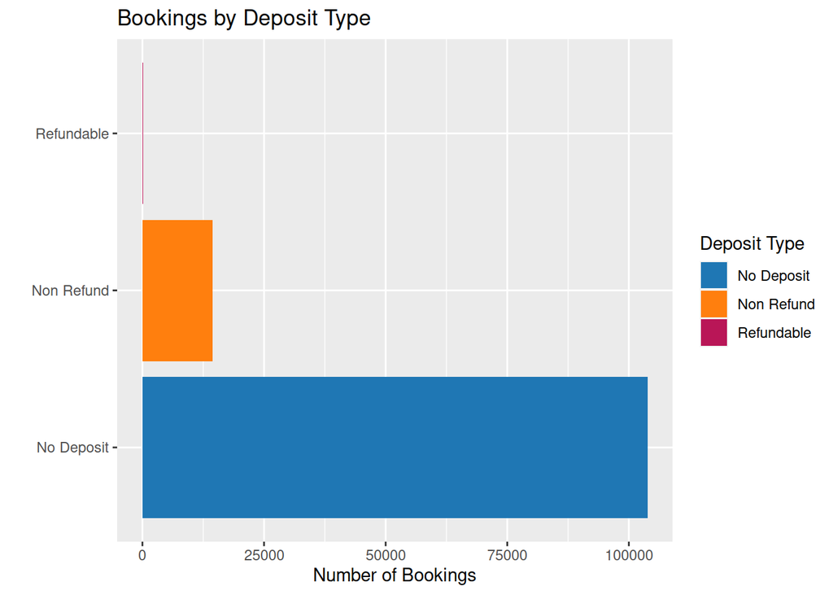

```r
ggplot() +
    geom_bar(aes(x = hotels$deposit_type, fill = hotels$deposit_type )) +
    coord_flip() +
    scale_fill_manual(values=c("#1F77B4","#FF7F0E","#B91657"))+
    labs(x = "",
         y = "Number of Bookings",
         fill = "Deposit Type",
         title = "Bookings by Deposit Type")
```

**Nhận xét:** Hầu như tất cả các đặt phòng đã được thực hiện mà không cần đặt cọc trước. Những vị khách này sẽ là thách thức lớn nhất đối với việc hủy phòng, vì họ không tạo ra bất kỳ doanh thu nào từ những vị khách này trong khi họ đang giữ phòng. Khi một khoản đặt cọc được thực hiện, nó hầu như luôn được thực hiện dưới dạng một khoản đặt cọc không hoàn lại. Chỉ một phần rất nhỏ trong số khách đặt cọc được hoàn lại.